# 2017: Revisiting the AL MVP Ballot

Sanjay Pothula

August 29, 2019

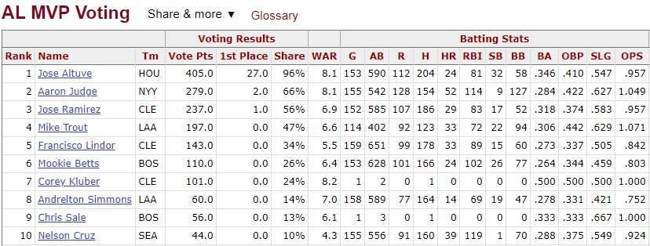

Though Jose Altuve and Aaron Judged finished tied in Baseball-Reference WAR, Altuve won the AL MVP by a significant margin. To get an idea about the reasoning for why voters liked Altuve, as one writer part of the voting process for the IBWAA described, he preferred the all-around play of Altuve over Judge, and, the fact that despite his small frame, he hits for power. In addition, Altuve showed the ability to make contact at a high rate and steal bases. Personally, I think that there is a fair argument that could be made for Jose Altuve being the MVP, but this reasoning seems too biased by putting too much emphasis on his size and ability to make contact. There is a fair argument to be made for 4 candidates; Aaron Judge, Jose Ramirez, Mike Trout, and Jose Altuve.

## The Case for Jose Altuve

The argument for Altuve as MVP revolves around his consistency throughout the season. He finished in the top 3 for batting performance (55.638 wRAA), in which he did not have a month where he finished below 130 wRC+. His 95% confidence interval for wOBA would place his floor at closer to average with his ceiling still being elite (.308 - .391). As a fielder, he would be considered by UZR to be average to below average. In terms of his team’s overall performance, the Astros won 100 games in a non-competitive division, which saw them win the division by an outstanding 21 game margin.

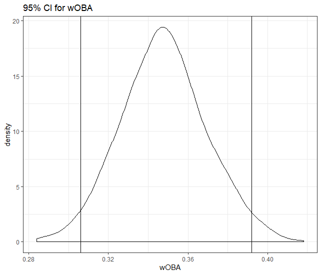

## The Case for Aaron Judge

He was the best overall hitter by the end of the season with a full season worth of plate appearances (79.54 wRAA). However, throughout July/August, he struggled significantly with a 35.9% strikeout rate, in which he struck out in 37 consecutive games. During this time period, he had a 102 wRC+. Even with this midseason struggle, his 95% confidence interval for wOBA would still place him as elite in terms of batting performance in 2017 (.329 - .421). In addition to be excellent in the box, he showed to be a strong fielder. In terms of his team’s overall performance, the Yankees got into the postseason as wild-card with 91 wins, finishing 2 games out of the division lead.

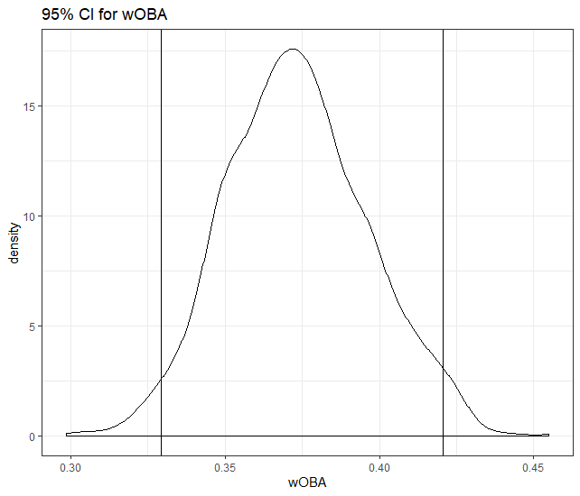

## The Case for Jose Ramirez

The argument for Jose Ramirez as the AL MVP would revolve around the overlap argument. Any statistic of a linear weight or percentage has a normalization factor, which a season’s worth of data is not strong enough to have an exactly precise number. Ramirez performed very well as a batter, but was not as strong as Judge, Altuve, and Trout (50.821 wRAA). In terms of fielding, he graded out as an average to above average fielder. In terms of team performance, the Cleveland Indians won the most games in the AL with 102 games, winning the division by a 17 game margin. It’s hard to make a convincing argument for Ramirez being the clear-cut MVP, but I can also see the margin between Ramirez and the 3 candidates not being overwhelmingly large.

## The Case for Mike Trout

Mike Trout finished the season as the second best batter (59.457 wRAA). This fact is so amazing because he missed 39 games after tearing a ligament in his thumb. The injury clearly cost him a shot at winning another MVP because, if you scale his performance to a full-season’s worth of plate appearances, he would likely lead in batting performance and WAR by a significant margin. As a fielder, he performed at an average to below average rate in terms of UZR. In terms of team performance, the Angels would not help his argument because they were very average at 80 wins, finishing 21 games out of the division lead and 5 games out of the final wild card spot.

## Personal Verdict

In the past, I thought Jose Altuve deserved the MVP from a purely consistency standpoint. However, after crunching the numbers, I would give my vote to Aaron Judge because he was a leader in batting performance and WAR by a pretty large margin. There is some overlap between the four players in terms of WAR. Yet, I don’t see that a 2 month period should weigh down Aaron Judge’s overall contribution because he was so strong in the beginning and end of the season to produce the statistics that he did.

|  | Name | Playerid | Season | PA | wOBA | wRAA | FRM | UZR | POS ADJ | Replacement | WAR |
| --- | --- | --- | --- | --- | --- | --- | --- | --- | --- | --- | --- |
| 1 | Aaron Judge | 15640 | 2017 | 678 | 0.373 | 79.541 | 0 | 6.1 | 1.69849108367627 | 14.0168518028396 | 10.9408832994944 |
| 2 | Joey Votto | 4314 | 2017 | 707 | 0.375 | 64.798 | 0 | 6 | 3.81673525377229 | 14.6163926616632 | 9.63203021539674 |
| 3 | Giancarlo Stanton | 4949 | 2017 | 692 | 0.356 | 52.211 | 0 | 8.3 | 1.79986282578875 | 14.3062853208924 | 8.27041754605798 |
| 4 | Charlie Blackmon | 7859 | 2017 | 725 | 0.357 | 51.591 | 0 | -0.9 | 7.4957475994513 | 14.9885214705881 | 7.89888483053102 |
| 5 | Anthony Rendon | 12861 | 2017 | 605 | 0.341 | 42.429 | 0 | 12.1 | 6.08827160493827 | 12.5076627444218 | 7.89345146258204 |
| 6 | Jose Ramirez | 13510 | 2017 | 645 | 0.342 | 50.821 | 0 | 4.4 | 3.9303840877915 | 13.3346156531439 | 7.82448183732031 |
| 7 | Mike Trout | 10155 | 2017 | 507 | 0.382 | 59.457 | 0 | -4.4 | 5.20164609053498 | 10.4816281180526 | 7.63603996206688 |
| 8 | Jose Altuve | 5417 | 2017 | 662 | 0.349 | 55.638 | 0 | -1.1 | 0.880041152263374 | 13.6860706393508 | 7.45942484797217 |
| 9 | Paul Goldschmidt | 9218 | 2017 | 665 | 0.349 | 47.741 | 0 | 3 | 3.54458161865569 | 13.7480921075049 | 7.3438766975562 |
| 10 | Nolan Arenado | 9777 | 2017 | 680 | 0.341 | 37.686 | 0 | 6.7 | 6.44835390946502 | 14.0581994482757 | 7.00480930027426 |

[output cut: 380 more lines]